# 生存分析作业

姜昊森 32023120063

2026-05-25

## 数据说明

31 名患晚期黑瘤症的病人经历综合治疗后记录的生存时间（按月计），其中带”+“号表示右删失数据。

```r
time_raw <- c("26.3+", "16.1", "24.0", "4.3", "31.3+", "94.0", "49.6",
              "77.9", "97.6+", "17.6+", "9.1", "27.3", "16.6+", "7.3",
              "16.3", "34.6+", "61.9+", "3.4", "75.6+", "9.4", "46.6+",
              "10.9", "14.3", "25.7", "22.4+", "13.0", "56.4", "88.7",
              "7.1", "64.4+", "9.1")

time <- as.numeric(gsub("\\+", "", time_raw))
status <- ifelse(grepl("\\+", time_raw), 0, 1)  # 0 = 删失，1 = 死亡
```

```r
# Kaplan-Meier 估计
fit_km <- survfit(Surv(time, status) ~ 1)
summary(fit_km)
```

```
## Call: survfit(formula = Surv(time, status) ~ 1)
##
##  time n.risk n.event survival std.err lower 95% CI upper 95% CI
##   3.4     31       1   0.9677  0.0317       0.9075        1.000
##   4.3     30       1   0.9355  0.0441       0.8529        1.000
##   7.1     29       1   0.9032  0.0531       0.8049        1.000
##   7.3     28       1   0.8710  0.0602       0.7606        0.997
##   9.1     27       2   0.8065  0.0710       0.6787        0.958
##   9.4     25       1   0.7742  0.0751       0.6402        0.936
##  10.9     24       1   0.7419  0.0786       0.6028        0.913
##  13.0     23       1   0.7097  0.0815       0.5666        0.889
##  14.3     22       1   0.6774  0.0840       0.5313        0.864
##  16.1     21       1   0.6452  0.0859       0.4969        0.838
##  16.3     20       1   0.6129  0.0875       0.4633        0.811
##  24.0     16       1   0.5746  0.0900       0.4227        0.781
##  25.7     15       1   0.5363  0.0918       0.3834        0.750
##  27.3     13       1   0.4950  0.0936       0.3418        0.717
##  49.6      9       1   0.4400  0.0980       0.2844        0.681
##  56.4      8       1   0.3850  0.1000       0.2314        0.641
##  77.9      4       1   0.2888  0.1121       0.1349        0.618
##  88.7      3       1   0.1925  0.1085       0.0638        0.581
##  94.0      2       1   0.0963  0.0870       0.0164        0.566
```

## (1) 指数分布、威布尔分布和对数正态分布的概率图

### 概率图原理

- **指数分布**：$S(t) = e^{-\lambda t}$，故 $-\ln \hat{S}(t)$ 对 $t$ 应呈过原点的直线。
- **威布尔分布**：$S(t) = \exp(-(\lambda t)^\alpha)$，故 $\ln(-\ln \hat{S}(t))$ 对 $\ln t$ 应呈直线，斜率为 $\alpha$。
- **对数正态分布**：$\Phi^{-1}(1 - S(t))$ 对 $\ln t$ 应呈直线，斜率为 $1/\sigma$。

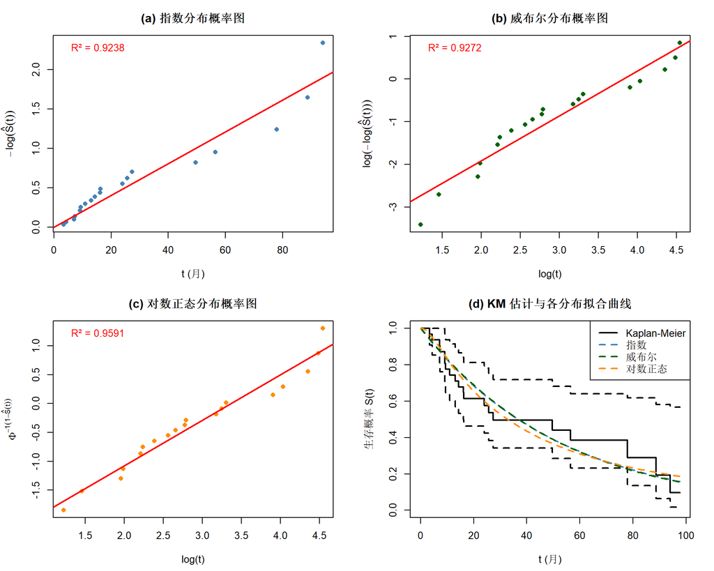

```r
km_summary <- summary(fit_km)
t_points <- km_summary$time
S_points <- km_summary$surv

par(mfrow = c(2, 2), mar = c(4.5, 4.5, 3, 2))
neg_log_S <- -log(S_points)
valid_idx <- S_points > 0 & S_points < 1
t_valid <- t_points[valid_idx]
neg_log_S_valid <- neg_log_S[valid_idx]
log_t <- log(t_valid)

# ---- (a) 指数分布 ----
plot(t_valid, neg_log_S_valid,
     xlab = "t (月)", ylab = expression(-log(hat(S)(t))),
     main = "(a) 指数分布概率图",
     pch = 16, col = "steelblue")
lm_exp0 <- lm(neg_log_S_valid ~ t_valid - 1)  # 过原点
abline(lm_exp0, col = "red", lwd = 2)
r2_exp <- summary(lm(neg_log_S_valid ~ t_valid))$r.squared
legend("topleft", legend = sprintf("R² = %.4f", r2_exp),
       bty = "n", text.col = "red")

# ---- (b) 威布尔分布 ----
log_log_S <- log(neg_log_S_valid)
plot(log_t, log_log_S,
     xlab = "log(t)", ylab = expression(log(-log(hat(S)(t)))),
     main = "(b) 威布尔分布概率图",
     pch = 16, col = "darkgreen")
lm_weib <- lm(log_log_S ~ log_t)
abline(lm_weib, col = "red", lwd = 2)
r2_weib <- summary(lm_weib)$r.squared
legend("topleft", legend = sprintf("R² = %.4f", r2_weib),
       bty = "n", text.col = "red")

# ---- (c) 对数正态分布 ----
qnorm_val <- qnorm(1 - S_points[valid_idx])
plot(log_t, qnorm_val,
     xlab = "log(t)", ylab = expression(Phi^{-1}(1 - hat(S)(t))),
     main = "(c) 对数正态分布概率图",
     pch = 16, col = "darkorange")
lm_lnorm <- lm(qnorm_val ~ log_t)
abline(lm_lnorm, col = "red", lwd = 2)
r2_lnorm <- summary(lm_lnorm)$r.squared
legend("topleft", legend = sprintf("R² = %.4f", r2_lnorm),
       bty = "n", text.col = "red")

# ---- (d) KM 曲线 + 三种分布拟合 ----
plot(fit_km, col = "black", lwd = 2,
     xlab = "t (月)", ylab = "生存概率 S(t)",
     main = "(d) KM 估计与各分布拟合曲线")
legend("topright",
       legend = c("Kaplan-Meier", "指数", "威布尔", "对数正态"),
       col = c("black", "steelblue", "darkgreen", "darkorange"),
       lwd = 2, lty = c(1, 2, 2, 2))

# 指数拟合 (MLE)
lambda_hat <- sum(status) / sum(time)
curve(exp(-lambda_hat * x), from = 0, to = max(time),
      col = "steelblue", lwd = 2, lty = 2, add = TRUE)

# 威布尔拟合 (survreg)
fit_weibull <- survreg(Surv(time, status) ~ 1, dist = "weibull")
shape_weib <- 1 / fit_weibull$scale
scale_weib <- exp(fit_weibull$coefficients)
curve(exp(-(x / scale_weib)^shape_weib), from = 0, to = max(time),
      col = "darkgreen", lwd = 2, lty = 2, add = TRUE)

# 对数正态拟合
fit_lnorm <- survreg(Surv(time, status) ~ 1, dist = "lognormal")
mu_lnorm <- fit_lnorm$coefficients
sigma_lnorm <- fit_lnorm$scale
curve(1 - pnorm((log(x) - mu_lnorm) / sigma_lnorm), from = 0, to = max(time),
      col = "darkorange", lwd = 2, lty = 2, add = TRUE)
```

各概率图的 R² 值汇总如下：

```r
r2_df <- data.frame(
  分布 = c("指数分布", "威布尔分布", "对数正态分布"),
  R_squared = round(c(r2_exp, r2_weib, r2_lnorm), 4)
)
r2_df
```

```
##           分布 R_squared
## 1     指数分布    0.9238
## 2   威布尔分布    0.9272
## 3 对数正态分布    0.9591
```

## (2) 分布选择与参数估计

### 图方法判断

概率图中，散点越接近直线，表明该分布对数据的拟合效果越好。从上面的三幅概率图及 R² 值判断：

- 指数分布的概率图偏离直线较为明显，R² 最低；
- 威布尔分布与对数正态分布的概率图线性程度较好。

### 参数估计

```r
# ---- 威布尔分布 ----
cat(sprintf("  形状参数 α = %.4f\n", shape_weib))
```

```
##   形状参数 α = 1.0133
```

```r
cat(sprintf("  尺度参数 scale = %.4f\n", scale_weib))
```

```
##   尺度参数 scale = 52.8638
```

```r
lambda_weib <- 1 / scale_weib
cat(sprintf("  即 S(t) = exp(-(%.4f × t)^%.4f)\n\n", lambda_weib, shape_weib))
```

```
##   即 S(t) = exp(-(0.0189 × t)^1.0133)
```

```r
# ---- 指数分布 ----
cat(sprintf("  λ = %.4f\n", lambda_hat))
```

```
##   λ = 0.0189
```

```r
cat(sprintf("  平均生存时间 = 1/λ = %.2f 月\n\n", 1/lambda_hat))
```

```
##   平均生存时间 = 1/λ = 52.94 月
```

```r
# ---- 对数正态分布 ----
cat(sprintf("  μ = %.4f\n", mu_lnorm))
```

```
##   μ = 3.4868
```

```r
cat(sprintf("  σ = %.4f\n", sigma_lnorm))
```

```
##   σ = 1.2291
```

```r
cat(sprintf("  即 log(T) ~ N(%.4f, %.4f²)\n\n", mu_lnorm, sigma_lnorm))
```

```
##   即 log(T) ~ N(3.4868, 1.2291²)
```

### AIC 比较

```r
aic_weib  <- AIC(fit_weibull)
aic_lnorm <- AIC(fit_lnorm)

aic_df <- data.frame(
  分布 = c("威布尔分布", "对数正态分布"),
  AIC = round(c(aic_weib, aic_lnorm), 2)
)
```

[output not shown]